# Biostat 212a Homework 6

### 1.5 Boosting forecaster (30pts)

- Use the same features as in AR($L$) for the boosting. Tune the boosting algorithm and evaluate the test performance.

```r
# Create lagged features for log_volume, DJIA_return, and log_volatility
L <- 5  # We will use AR(5) model, so L = 5

NYSE_lagged <- NYSE %>%
  mutate(
    lag_log_volume_1 = lag(log_volume, 1),
    lag_log_volume_2 = lag(log_volume, 2),
    lag_log_volume_3 = lag(log_volume, 3),
    lag_log_volume_4 = lag(log_volume, 4),
    lag_log_volume_5 = lag(log_volume, 5),

    lag_DJ_return_1 = lag(DJ_return, 1),
    lag_DJ_return_2 = lag(DJ_return, 2),
    lag_DJ_return_3 = lag(DJ_return, 3),
    lag_DJ_return_4 = lag(DJ_return, 4),
    lag_DJ_return_5 = lag(DJ_return, 5),

    lag_log_volatility_1 = lag(log_volatility, 1),
    lag_log_volatility_2 = lag(log_volatility, 2),
    lag_log_volatility_3 = lag(log_volatility, 3),
    lag_log_volatility_4 = lag(log_volatility, 4),
    lag_log_volatility_5 = lag(log_volatility, 5)
  ) %>%
  filter(complete.cases(.))  # Remove rows with NA values caused by lagging

# Split data into training (before 1980) and test (after 1980)
train_data <- NYSE_lagged %>% filter(date < "1980-01-01")
test_data <- NYSE_lagged %>% filter(date >= "1980-01-01")

# Prepare the training data matrix and target variable
X_train <- train_data %>% select(starts_with("lag_"))
y_train <- train_data$log_volume

# Prepare the test data matrix and target variable
X_test <- test_data %>% select(starts_with("lag_"))
y_test <- test_data$log_volume

# Convert the data to matrix format for xgboost
X_train_matrix <- as.matrix(X_train)
X_test_matrix <- as.matrix(X_test)

# Set up a training control object for tuning (use 5-fold cross-validation)
train_control <- trainControl(method = "cv", number = 5)

# Set up the correct tuning grid
tune_grid <- expand.grid(
  nrounds = c(10, 50, 100),           # boosting iterations
  max_depth = c(3, 5),             # Limit max_depth
  eta = c(0.01, 0.1),              # Use smaller eta values
  gamma = c(0, 0.1),               # Reduce gamma values
  colsample_bytree = c(0.7),       # Keep colsample_bytree constant
  subsample = c(0.7),              # Keep subsample constant
  min_child_weight = c(1)          # Reduce min_child_weight values
)


# Train the xgboost model with tuning
xgb_tune <- train(
  x = X_train_matrix,
  y = y_train,
  method = "xgbTree",  # Use xgboost algorithm
  trControl = train_control,
  tuneGrid = tune_grid
)
```

[output not shown]

[output cut: 25 more lines]

[output not shown]

```r
# View the best-tuned parameters
print(xgb_tune$bestTune)
```

```
   nrounds max_depth eta gamma colsample_bytree min_child_weight subsample
23      50         5 0.1   0.1              0.7                1       0.7
```

```r
# Make predictions on the test set
y_pred_xgb <- predict(xgb_tune, X_test_matrix)

# Calculate R^2 on the test set
rss_xgb <- sum((y_test - y_pred_xgb)^2)
tss_xgb <- sum((y_test - mean(y_test))^2)
r_squared_xgb <- 1 - (rss_xgb / tss_xgb)

# Print the R^2 value
print(paste("R^2 for xgboost model:", r_squared_xgb))
```

```
[1] "R^2 for xgboost model: 0.399718942904959"
```

- Hint: [Workflow: Boosting tree for Prediction](https://ucla-biostat-212a.github.io/2025winter/slides/08-tree/workflow_boosting_reg.html) is a good starting point.

### 1.6 Summary (30pts)

Your score for this question is largely determined by your final test performance.

```r
# Extract CV R² from the Random Forest model
print("Random Forest Cross-Validation R² values:")
```

```
[1] "Random Forest Cross-Validation R² values:"
```

```r
print(rf_tune$results[, c("mtry", "RMSE", "Rsquared")])
```

```
  mtry      RMSE  Rsquared
1    2 0.1528053 0.5678504
2    4 0.1506684 0.5751785
3    6 0.1505068 0.5749832
4    8 0.1504274 0.5750853
5   10 0.1506068 0.5739720
```

```r
# Predict on the test set
rf_predictions <- predict(rf_tune, newdata = test_data)

# Calculate test R²
rf_test_r2 <- cor(rf_predictions, test_data$log_volume)^2
print(paste("Random Forest Test R²:", rf_test_r2))
```

```
[1] "Random Forest Test R²: 0.405179851768356"
```

```r
# Extract CV R² from the XGBoost model
print("XGBoost Cross-Validation R² values:")
```

```
[1] "XGBoost Cross-Validation R² values:"
```

```r
print(xgb_tune$results[, c("nrounds", "max_depth", "eta", "Rsquared")])
```

```
   nrounds max_depth  eta  Rsquared
1       10         3 0.01 0.5308519
4       10         3 0.01 0.5198295
13      10         3 0.10 0.5300091
16      10         3 0.10 0.5332997
7       10         5 0.01 0.5363132
10      10         5 0.01 0.5345867
19      10         5 0.10 0.5488803
22      10         5 0.10 0.5461407
2       50         3 0.01 0.5384519
5       50         3 0.01 0.5360909
14      50         3 0.10 0.5680117
17      50         3 0.10 0.5663948
8       50         5 0.01 0.5505538
11      50         5 0.01 0.5538057
20      50         5 0.10 0.5679220
23      50         5 0.10 0.5733539
3      100         3 0.01 0.5430952
6      100         3 0.01 0.5423875
15     100         3 0.10 0.5716494
18     100         3 0.10 0.5695958
9      100         5 0.01 0.5589520
12     100         5 0.01 0.5606778
21     100         5 0.10 0.5643659
24     100         5 0.10 0.5695294
```

```r
# Predict on the test set
xgb_predictions <- predict(xgb_tune, newdata = test_data)

# Calculate test R²
xgb_test_r2 <- cor(xgb_predictions, test_data$log_volume)^2
print(paste("XGBoost Test R²:", xgb_test_r2))
```

```
[1] "XGBoost Test R²: 0.403411478452984"
```

[output not shown]

## 2 ISL Exercise 12.6.13 (90 pts)

On the book website, www.statlearning.com, there is a gene expression data set (Ch12Ex13.csv) that consists of 40 tissue samples with measurements on 1,000 genes. The first 20 samples are from healthy patients, while the second 20 are from a diseased group.

1. Load in the data using read.csv(). You will need to select header = F.

```r
#load dataset
url <- "http://www.statlearning.com/s/Ch12Ex13.csv"
ch12Ex13 <- read_csv(url, col_names = paste("ID", 1:40))


# Check the first few rows of the data
head(data)
```

[output not shown]

2. Apply hierarchical clustering to the samples using correlation based distance, and plot the dendrogram.

```r
#set up hierarchical clustering model (average linkage)

set.seed(123) #set seed for reproducability

data_transposed <- as.data.frame(t(ch12Ex13)) #transpose data

hc_spec <- hier_clust(
  # num_clusters = 3
  linkage_method = "average"
)

hc_fit <- hc_spec |>
  fit(~.,
      data = data_transposed
    )

hc_fit |>
  summary()
```

```
        Length Class      Mode
spec    4      hier_clust list
fit     7      hclust     list
elapsed 1      -none-     list
preproc 4      -none-     list
```

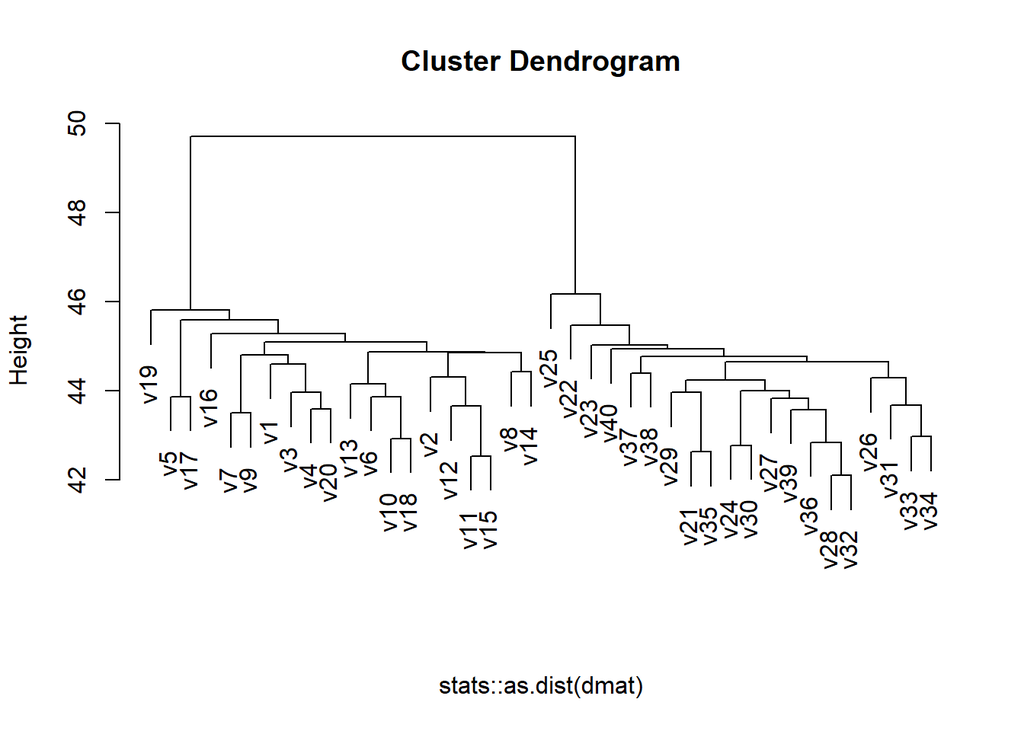

```r
hc_fit$fit |> plot(sub = "")
```

Do the genes separate the samples into the two groups?

Yes we can see clearly that the samples are divided into two groups. Samples 1- 20 are in one cluster, while samples 21-40 are in another cluster.

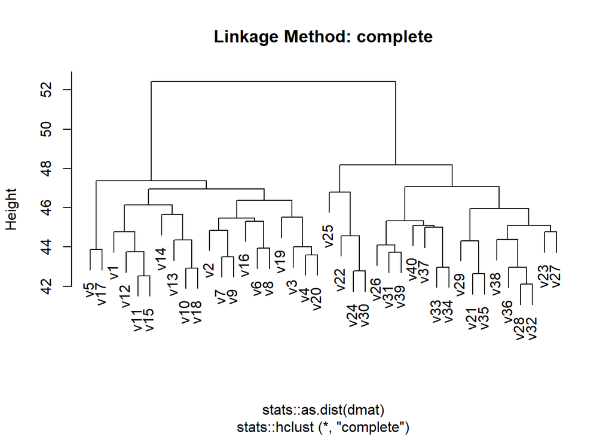

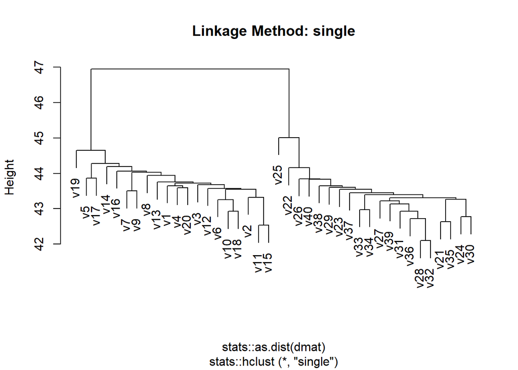

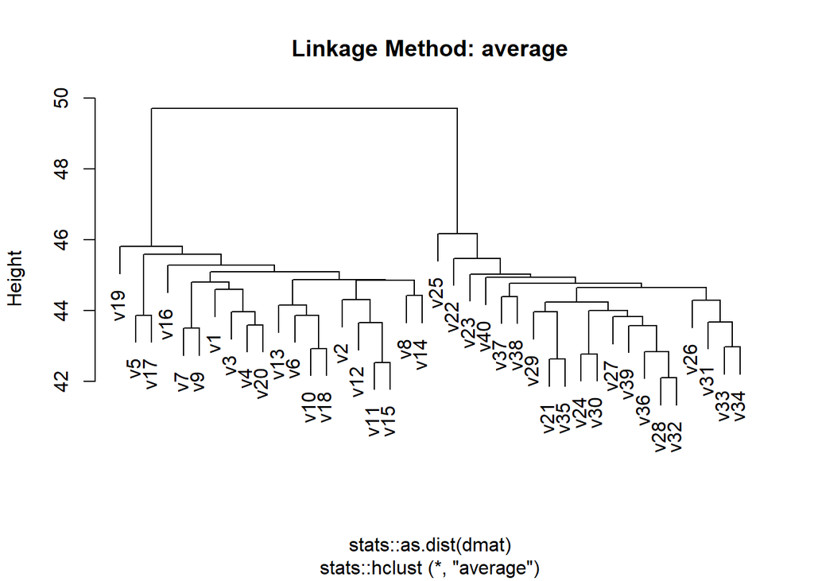

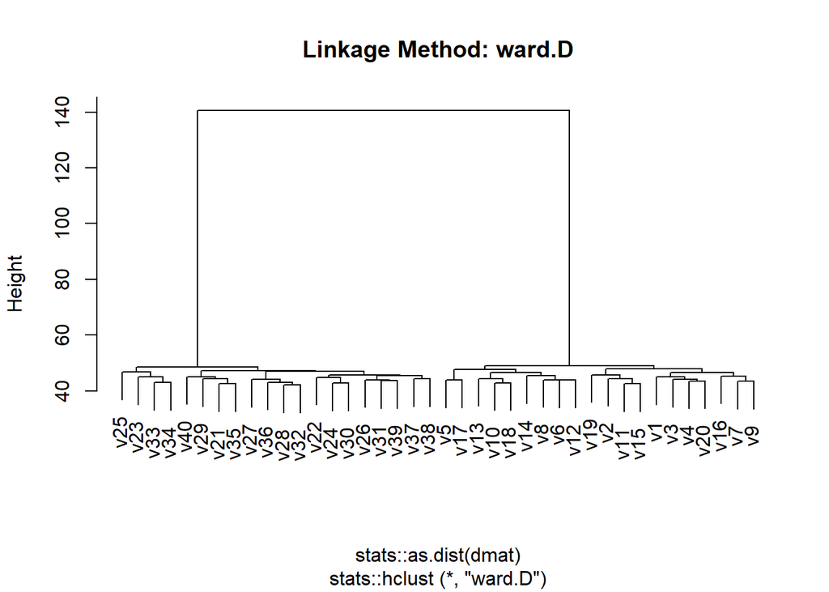

[figure not shown]

```r
#different linkage methods

set.seed(123) # set seed for reproducibility

# Define the list of linkage methods
linkage_methods <- c("complete", "single", "average", "ward.D", "centroid")

# Iterate through the linkage methods and plot the clustering results
par(mfrow = c(1, 1)) # Arrange the plots in a grid (2 rows, 3 columns)

for (method in linkage_methods) {
  hc_spec <- hier_clust(
    linkage_method = method
  )

  hc_fit <- hc_spec |>
    fit(~.,
        data = data_transposed
      )

  # Plot the dendrogram for the current linkage method
  hc_fit$fit |> plot(main = paste("Linkage Method:", method))
}
```

Do your results depend on the type of linkage used?

### 2.1 PCA and UMAP (30 pts)

Now we want to see the clusters from the genes using a PCA map and a UMAP. We can see there is a clear clustering of 2 groups from both the UMAP and the PCA graphs. This helps us confirm there is a distinct difference between these two groups we saw from the dendrogram.

```r
# Hierarchical clustering (average linkage)
set.seed(123) # set seed for reproducibility

# Add the "status" labels: first 20 "healthy", next 20 "diseased"
status <- c(rep("healthy", 20), rep("diseased", 20))

# Check the status labels
head(status)
```

```
[1] "healthy" "healthy" "healthy" "healthy" "healthy" "healthy"
```

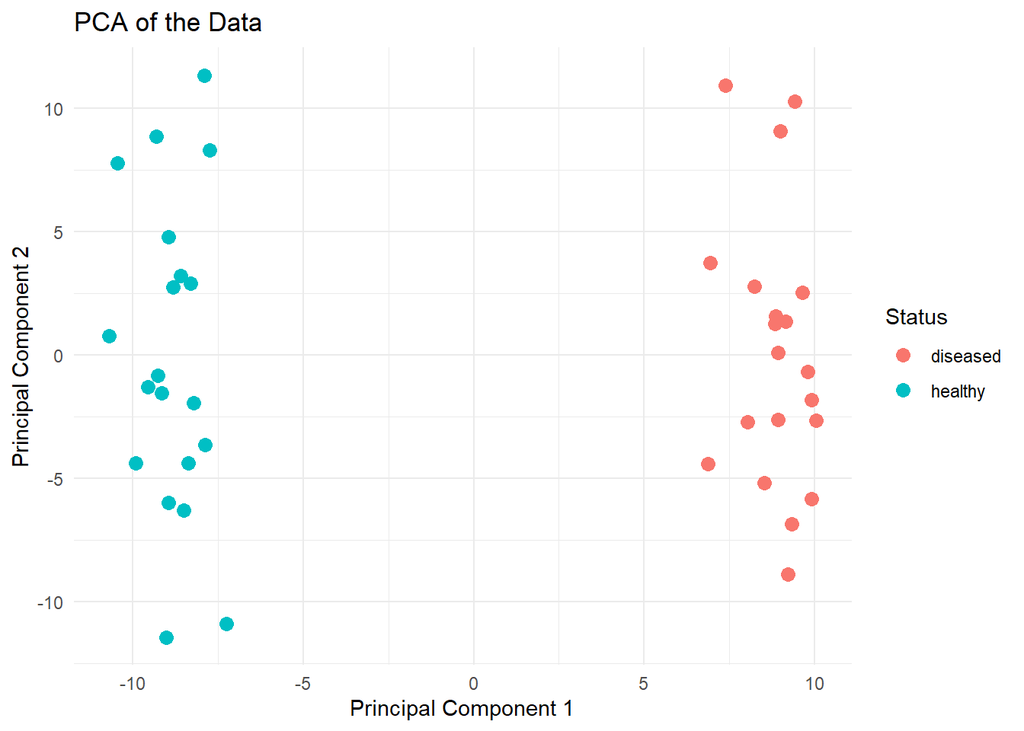

```r
# Perform PCA
pca_result <- prcomp(data_transposed, center = TRUE, scale. = TRUE)

# Create PCA data frame
pca_data <- data.frame(pca_result$x) # Extract PCA components
pca_data$Status <- factor(status) # Add "status" to the PCA data frame

# PCA plot with "status" coloring
ggplot(pca_data, aes(x = PC1, y = PC2, color = Status)) +
  geom_point(size = 3) +
  labs(title = "PCA of the Data", x = "Principal Component 1", y = "Principal Component 2") +
  theme_minimal()
```

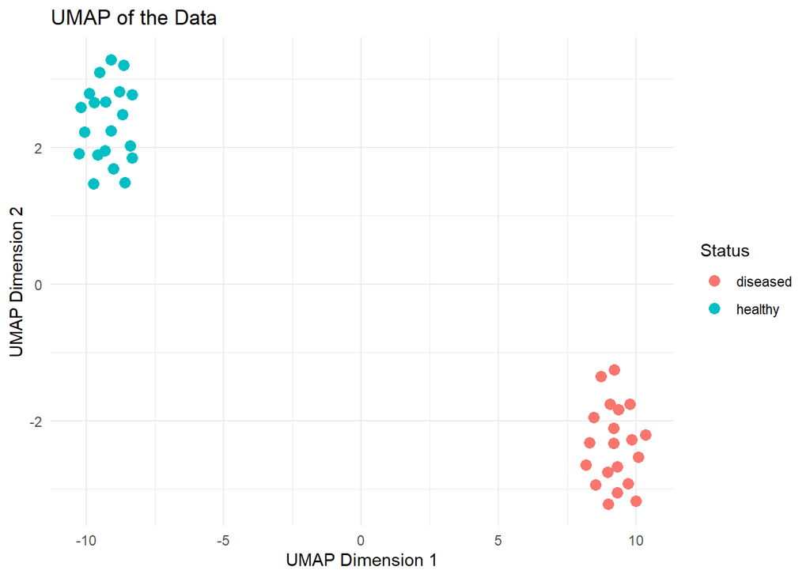

```r
# UMAP Plot

# Perform UMAP
umap_result <- umap(data_transposed)

# Create UMAP data frame
umap_data <- data.frame(umap_result$layout)

# Rename columns for clarity
colnames(umap_data) <- c("UMAP1", "UMAP2")  # Rename the UMAP dimensions

# Add "status" to the UMAP data frame
umap_data$Status <- factor(status)

# UMAP plot with "status" coloring
ggplot(umap_data, aes(x = UMAP1, y = UMAP2, color = Status)) +
  geom_point(size = 3) +
  labs(title = "UMAP of the Data", x = "UMAP Dimension 1", y = "UMAP Dimension 2") +
  theme_minimal()
```

### 2.2 12.6.13 (c) (30 pts)

Your collaborator wants to know which genes differ the most across the two groups. Suggest a way to answer this question, and apply it here.

What we can first do is cut our dendrogram to form two groups. These groups will correspond to the experimental groups we are interested in comparing.

We can perform a differential expression analysis (t-test) for each gene.

For each gene a t-test is performed comparing the expression values between the two groups. The t-test checks if there is a significant difference in gene expression between the two groups for each individual gene. The null hypothesis is that the mean expression level is the same in both groups, and the alternative hypothesis is that they are different. We then iterate over each row (gene) of the transposed data and run the t-test for each gene.

```r
# Add status to the data (assuming `status` is already defined: "healthy" and "diseased")
# We assume `data_transposed` has genes as columns and samples as rows

# Create a data frame to hold the t-test results
t_test_results <- data.frame(Gene = colnames(data_transposed),
                             P_Value = NA,
                             Diff_Mean = NA)

# Perform the t-test for each gene
for (gene in colnames(data_transposed)) {
  # Perform t-test comparing "healthy" vs. "diseased"
  t_test <- t.test(data_transposed[status == "healthy", gene],
                   data_transposed[status == "diseased", gene])

  # Store the p-value and the mean difference in the results
  t_test_results[t_test_results$Gene == gene, "P_Value"] <- t_test$p.value
  t_test_results[t_test_results$Gene == gene, "Diff_Mean"] <-
    mean(data_transposed[status == "diseased", gene]) -
    mean(data_transposed[status == "healthy", gene])
}

# Sort by p-value (smallest to largest) to identify the most significant genes
t_test_results_sorted <- t_test_results[order(t_test_results$P_Value), ]

# Display the top 10 most significant genes
head(t_test_results_sorted, 10)
```

```
    Gene      P_Value Diff_Mean
502 V502 1.530472e-12  2.544461
589 V589 6.511864e-12  2.343491
600 V600 1.003599e-11  2.747577
590 V590 1.123456e-10  2.205324
565 V565 1.765864e-10  2.470820
551 V551 1.195743e-09  2.342845
593 V593 1.350119e-09  2.402096
584 V584 2.132610e-09  2.601985
538 V538 2.548944e-09  2.391979
569 V569 2.830488e-09  1.976160
```

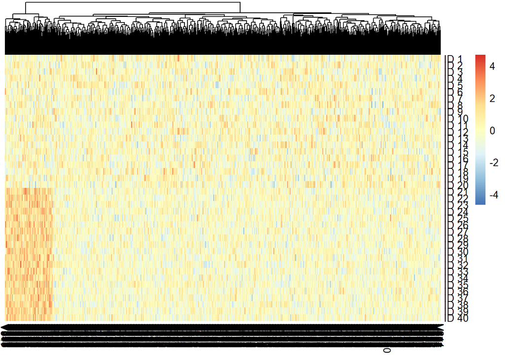

```r
library(pheatmap)

pheatmap(data_transposed, cluster_rows = FALSE, cluster_cols = T, scale ="row",
         annotiation_colors = list(status = c(disease ="orange", healthy = "black",
                                              color = colorRampPalette(c("navy", "white", "red"))(50))))
```